# TA Section: spatial data types, tmap and geocoding tips and warnings

## 5 - Other tmap features

## 5.1 - Animations:

- Animation is not interactivity. It’s just a moving maps like a GIF.
- Sometimes facets can be difficult to compare, specially if they are too many.
- Animations can help to make comparisons easier.
- It’s relatively easy to make animations with “tmap_animation” by creating .gif. Check this animation of the exercise above:

```r
# First some data Wrangling to keep all the months from July to December.
data <- covid19()
sub_data <- data %>%
  filter(as.character(date) %in% c("2020-07-31",
                                   "2020-08-31",
                                   "2020-09-30",
                                   "2020-10-31",
                                   "2020-11-30",
                                   "2020-12-31")) %>%
  mutate(month = months(date), per_recovered = (recovered/population)*100) %>%
  dplyr::select(month, id, per_recovered)
# Second, we merge the world shape data with Covid data.
data("World", package = "tmap")
merged <- World %>%
  merge(sub_data, by.x = "iso_a3", by.y = "id")

# Then, we crop once again the merged data with the European coastline shapefile
merged_croped <- crop_shape(merged %>%
                              filter(continent == "Europe"), europe, polygon =  FALSE)
# One final step is that we use factors to re-order the maps.
merged_croped <- merged_croped %>%
  mutate(month = as.factor(month) %>%
             forcats::fct_relevel("July", "August", "September", "October", "November", "December"))
# We are Ready!
```

The animation syntax has two parts. First, writing a code that is almost the same as if we were doing small multiples with tm_facets but instead of using by = "“, we will use”along".

```r
# We first just build the map using the option along in facets.
animation <- tm_shape(merged_croped) +
  tm_polygons(col = "per_recovered", title = "Percentage of the \n population recovered\n from COVID", palette = "BuPu") +
  tm_facets(along = "month", free.scales.symbol.size = FALSE) +
  tm_layout(scale = 4, panel.label.size = 10, main.title.size = 10)

# Then we use tmap animation: and that's all!
tmap_animation(
  animation, filename = "europe.gif",
  delay = 50, width = 2400, height = 1200, scale = 4
  )
```

Voila!

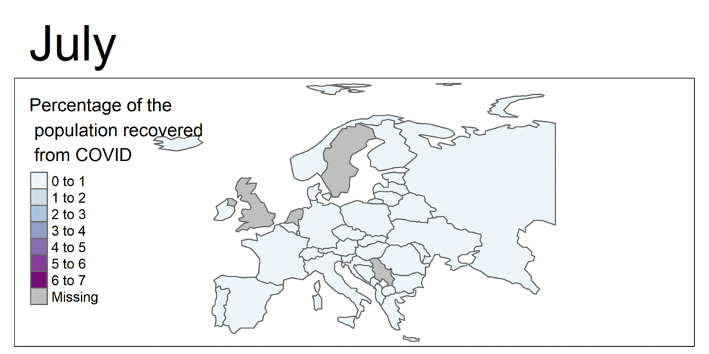

Example of an animated map

## 5.2 - qtmap:

- qtmap: Quick ThematicQuick Thematic Map (qtm). It’s a does the same as tmap, it’s a tmap object but without having to stack many elements and can save you come coding.
- Remember the dot map of crimes in greater London?
- You can save some lines of codes. This syntax allows you to get exactly the same map.

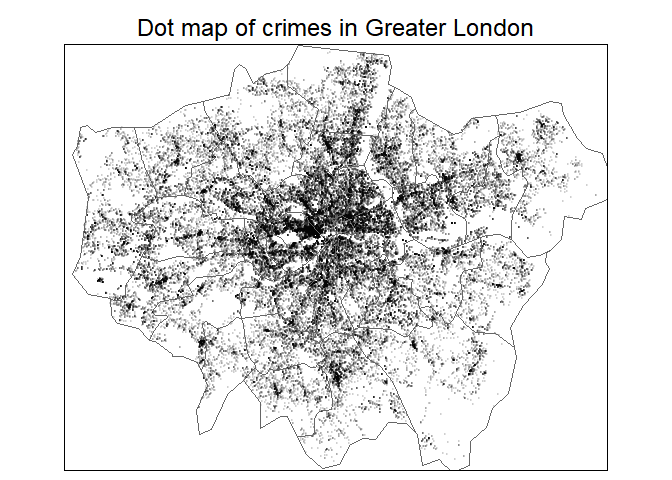

```r
# You could get the same results using qtm:
qtm(crimes_london, dots.alpha = 0.1) +
  tm_shape(london) +
 tm_borders() + tm_layout(main.title = "Dot map of crimes in Greater London",  main.title.position = "center")
```

```r
# The old syntax:
#tm_shape(crimes_london) +
#tm_dots(alpha = 0.1) + # Makes the dots smaller by usingZ
#tm_shape(london) +
#tm_borders() + tm_layout(main.title = "Dot map of crimes in Greater London",  main.title.position = "center")
```

Here is another example of a map with qtm in one line of code:

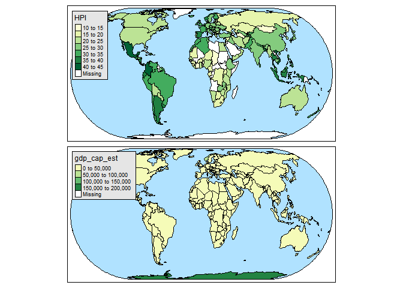

```r
qtm(World, fill = c("HPI", "gdp_cap_est"), style = "natural")
```

## 6 - Geocoding tips and warnings: You don’t always get what you want

When you geocode addresses using google, sometimes the coordinates you get are not the address you are looking for.

Open the googlemaps website and look for the following addresses:

- Example 1: 2747 Amalfi Drive, Holiday, FL

The address does not exist, however you will get something in return.

- Example 2: 3818 Lemon Avenue, FL

There are many addresses that match this one. Therefore, if you get one address (which happens with some packages) you don’t know which one is the right one.

- Example 3 Roosevelt Dr and Register Rd, Polk County

If the address was this one: “Roosevelt Dr and Register Rd, Polk County, Florida”, you would have gotten what you were looking for. So, the more information the better.

*Solution*

You need a command that helps you to control the quality of your geocoding. One alternative is googleway. You can control many of these aspects by taking advantage of all of the information that is retrieved from google. If you want more information about this I can show you some examples in my office hours.

You can also start by enabling and setting your google key, and then running the follwing code:

```r
# With googleway:
# -------------- #
# ob <- google_geocode(address = "Downtown Miami, Miami, FL", simplify = TRUE) # We geocode downtown Miami
```

The main lesson is: *be careful when geocoding*.

## 7. Short survey

$~$

[Here](https://forms.gle/XQQziyvpnZX1tMYY7) a short survey for asynchronous learners. It’s anonymous, I just want to check how many people are looking this material and if you have any comment. Thank you!

$~$

$~$